# 資料分析師的工具箱：回顧 2022 Kaggle 普查

[數聚點](https://www.datainpoint.com) | 郭耀仁 yaojenkuo@datainpoint.com

## 關於我

- Hahow 線上課程講師
  - [如何成為資料分析師](https://hahow.in/cr/dajourney)
  - [SQL 的五十道練習](https://hahow.in/cr/sqlfifty)
  - [Python 的 50+ 練習](https://hahow.in/cr/pythonfiftyplus)
  - [R 語言的 50+ 練習](https://hahow.in/cr/rfiftyplus)
- 台大工管系兼任講師
- 台大資工系統訓練班資深講師（授課時數 2,000+ 小時）
- [我的 Medium](https://medium.com/datainpoint)
- [我的 Substack](https://datainpoint.substack.com)

## 關於我（續）

- 工作經歷
  - 資深資料分析師（Coupang 韓領網路科技）
  - 分析顧問（台灣賽仕電腦軟體）
  - 儲備幹部（中國信託商業銀行）
  - 研究助理（台灣麥肯錫）
- 學歷
  - 台灣大學商學研究所
  - 台灣大學工商管理系

## 誰是「資料分析師」

透過邏輯、事實以及量化作為基準、透過程式來處理並分析資料，進而拆解問題、並尋求解答的專業人士，很有可能是一位「擅長寫程式的分析師」、也可能是一位「擅長分析的程式設計師」。

## Kaggle 機器學習與資料科學調查

## 什麼是 Kaggle

> Kaggle 是一個機器學習與資料分析競賽平台，企業會在 Kaggle 發佈競賽資料供資料科學家訓練、建立模型並與其他的參賽者比較模型的準確度。於 2017 年被 Google 收購。

來源：https://en.wikipedia.org/wiki/Kaggle

## 關於 Kaggle 機器學習與資料科學調查

- 從 2017 年起寄送電子問卷給網站會員填寫。
- 至今年（2022 年）已經連續六屆都有舉辦調查與資料分析競賽。
- 今年（2022 年）有效填寫人數有 23,997 位會員。

來源：https://www.kaggle.com/c/kaggle-survey-2022

## 關於 Kaggle 機器學習與資料科學調查（續）

- [Methodology](https://classroom-data-analysts-toolbox.s3.ap-northeast-3.amazonaws.com/kaggle_survey_2022_methodology.pdf)
- [Answer choices](https://classroom-data-analysts-toolbox.s3.ap-northeast-3.amazonaws.com/kaggle_survey_2022_answer_choices.pdf)
- kaggle_survey_2022_responses.csv

來源：https://www.kaggle.com/c/kaggle-survey-2022

## 可以開啟一個 Google Colab 來 Code along

前往 [Google Colab](https://colab.research.google.com) 新增筆記本。

## 什麼是 Google Colab？

> Colab 是由 Collaborate 與 Laboratory 兩個單字組合而成，意義為可以協作的 Jupyter Notebook。Google Colab 之於 Jupyter Notebook 就如同 Google Docs 之於 Microsoft Word、Google Sheets 之於 Microsoft Excel 一般。

## Google Colab 快速入門

- 前往 [Google Colab](https://colab.research.google.com) 新增筆記本（New notebook）。
- 登入 Google 帳戶。
- 點選 `Connect` 連線取得算力（Computing power）。
- 點選 `+ Code` 增加程式碼儲存格。
- 點選 `+ Text` 增加文字儲存格。

## Google Colab 快速入門（續）

- 點選程式碼儲存格左側的「執行」按鈕執行該程式碼儲存格。
- 點選 Runtime -> Run all 執行 Google Colab 中所有的儲存格。

```python
print("Hello, world!")
print("Hello, Python!")
```

```
Hello, world!
Hello, Python!
```

## Google Colab 快速入門（續）

- 點選 File -> Save a copy in drive 另存複本到雲端硬碟。
- 點選 Help 調整為英文使用介面。
- 點選 Tools -> Settings 調整使用介面。
  - Site -> Theme 調整佈景主題。
  - Miscellaneous 邀請柯基、小貓或螃蟹陪我們寫程式。

## Code along 的完整筆記本

- https://colab.research.google.com/drive/1-Ad0hMwBDEVPM65x7ZL3tbIjmOl_6_bJ?usp=sharing
- 點選 File -> Save a copy in drive 另存複本到雲端硬碟。

```python
import pandas as pd
import matplotlib.pyplot as plt
```

```python
csv_file_path = "https://raw.githubusercontent.com/datainpoint/classroom-data-analysts-toolbox/main/kaggle_survey_2022_responses.csv"
first_two_lines = pd.read_csv(csv_file_path, nrows=1)
temp_df = pd.read_csv(csv_file_path, skiprows=[1], low_memory=False)
survey_data = temp_df.drop('Duration (in seconds)', axis=1)
first_two_lines
```

|  | Duration (in seconds) | Q2 | Q3 | Q4 | Q5 | Q6_1 | Q6_2 | Q6_3 | Q6_4 | Q6_5 | ... | Q44_3 | Q44_4 | Q44_5 | Q44_6 | Q44_7 | Q44_8 | Q44_9 | Q44_10 | Q44_11 | Q44_12 |
| --- | --- | --- | --- | --- | --- | --- | --- | --- | --- | --- | --- | --- | --- | --- | --- | --- | --- | --- | --- | --- | --- |
| 0 | Duration (in seconds) | What is your age (# years)? | What is your gender? - Selected Choice | In which country do you currently reside? | Are you currently a student? (high school, uni... | On which platforms have you begun or completed... | On which platforms have you begun or completed... | On which platforms have you begun or completed... | On which platforms have you begun or completed... | On which platforms have you begun or completed... | ... | Who/what are your favorite media sources that ... | Who/what are your favorite media sources that ... | Who/what are your favorite media sources that ... | Who/what are your favorite media sources that ... | Who/what are your favorite media sources that ... | Who/what are your favorite media sources that ... | Who/what are your favorite media sources that ... | Who/what are your favorite media sources that ... | Who/what are your favorite media sources that ... | Who/what are your favorite media sources that ... |

1 rows × 296 columns

```python
survey_data.head()
```

|  | Q2 | Q3 | Q4 | Q5 | Q6_1 | Q6_2 | Q6_3 | Q6_4 | Q6_5 | Q6_6 | ... | Q44_3 | Q44_4 | Q44_5 | Q44_6 | Q44_7 | Q44_8 | Q44_9 | Q44_10 | Q44_11 | Q44_12 |
| --- | --- | --- | --- | --- | --- | --- | --- | --- | --- | --- | --- | --- | --- | --- | --- | --- | --- | --- | --- | --- | --- |
| 0 | 30-34 | Man | India | No | NaN | NaN | NaN | NaN | NaN | NaN | ... | NaN | NaN | NaN | NaN | NaN | NaN | NaN | NaN | NaN | NaN |
| 1 | 30-34 | Man | Algeria | No | NaN | NaN | NaN | NaN | NaN | NaN | ... | NaN | NaN | NaN | NaN | NaN | NaN | NaN | NaN | NaN | NaN |
| 2 | 18-21 | Man | Egypt | Yes | Coursera | edX | NaN | DataCamp | NaN | Udacity | ... | NaN | Kaggle (notebooks, forums, etc) | NaN | YouTube (Kaggle YouTube, Cloud AI Adventures, ... | Podcasts (Chai Time Data Science, O’Reilly Dat... | NaN | NaN | NaN | NaN | NaN |
| 3 | 55-59 | Man | France | No | Coursera | NaN | Kaggle Learn Courses | NaN | NaN | NaN | ... | NaN | Kaggle (notebooks, forums, etc) | Course Forums (forums.fast.ai, Coursera forums... | NaN | NaN | Blogs (Towards Data Science, Analytics Vidhya,... | NaN | NaN | NaN | NaN |
| 4 | 45-49 | Man | India | Yes | NaN | NaN | NaN | NaN | NaN | NaN | ... | NaN | NaN | NaN | NaN | NaN | Blogs (Towards Data Science, Analytics Vidhya,... | NaN | NaN | NaN | NaN |

5 rows × 295 columns

```python
# Number of respondants
survey_data.shape[0]
```

```
23997
```

```python
question_indices = [col_name[0] for col_name in survey_data.columns.str.split("_")]
question_descriptions = first_two_lines.values.ravel()[1:]
tidy_question_descriptions = [desc.split(" - ")[0] for desc in question_descriptions]
unique_question_indices = pd.Series(question_indices).unique()
unique_question_descriptions = pd.Series(tidy_question_descriptions).unique()
question_types = ["Multiple Response" if "(Select all that apply)" in desc else "Multiple Choice" for desc in unique_question_descriptions]
question_table = pd.DataFrame()
question_table["question_index"] = unique_question_indices
question_table["question_type"] = question_types
question_table["question_description"] = unique_question_descriptions
question_table.head()
```

|  | question_index | question_type | question_description |
| --- | --- | --- | --- |
| 0 | Q2 | Multiple Choice | What is your age (# years)? |
| 1 | Q3 | Multiple Choice | What is your gender? |
| 2 | Q4 | Multiple Choice | In which country do you currently reside? |
| 3 | Q5 | Multiple Choice | Are you currently a student? (high school, uni... |
| 4 | Q6 | Multiple Response | On which platforms have you begun or completed... |

```python
# Types of question
question_table.value_counts("question_type")
```

```
question_type
Multiple Response    24
Multiple Choice      19
dtype: int64
```

```python
# Respondant titles
survey_data["Q23"].value_counts()
```

```
Data Scientist                                                      1929
Data Analyst (Business, Marketing, Financial, Quantitative, etc)    1538
Currently not employed                                              1432
Software Engineer                                                    980
Teacher / professor                                                  833
Manager (Program, Project, Operations, Executive-level, etc)         832
Other                                                                754
Research Scientist                                                   593
Machine Learning/ MLops Engineer                                     571
Engineer (non-software)                                              465
Data Engineer                                                        352
Statistician                                                         125
Data Architect                                                        95
Data Administrator                                                    70
Developer Advocate                                                    61
Name: Q23, dtype: int64
```

```python
# Filtering Data Analyst out
survey_data_analysts = survey_data[survey_data["Q23"] == "Data Analyst (Business, Marketing, Financial, Quantitative, etc)"]
survey_data_analysts.shape[0]
```

```
1538
```

## 透過 Kaggle 機器學習與資料科學調查探索資料分析師日常的工作內容與使用工具

- 主要工作內容。
- 程式語言。
- 整合開發環境、純文字編輯器。
- 視覺化模組、套件。
- 商業智能軟體。
- 機器學習模組、套件。
- 關聯式資料庫管理系統。

## 什麼是整合開發環境

> 寫作與執行程式需要三種類型的電腦軟體，包含純文字編輯器、終端機與直譯器（或編譯器），其中純文字編輯器能用來編寫程式、終端機能用來執行程式、直譯器（或編譯器）能將程式語言翻譯為電腦語言，整合開發環境就是將前述三者整合在一起的軟體。

來源：https://en.wikipedia.org/wiki/Integrated_development_environment

## 什麼是純文字編輯器

> 純文字編輯器主要用於編寫和檢視純文字檔案，因為程式與資料通常以純文字形式儲存，也就是不帶有格式（標題、段落或者項目符號等）的內容，所以程式設計師需要使用純文字編輯器來編輯程式、檢視資料。

來源：https://en.wikipedia.org/wiki/Text_editor

## 什麼是模組、套件

> 程式語言組織程式碼的一種結構機制，透過模組、套件的開發管理，能夠實踐軟體工程中的 DRY(Don't Repeat Yourself)準則，現代軟體開發往往利用模組作為組裝單位，能分開地被編寫、允許同時協作。

來源：https://en.wikipedia.org/wiki/Modular_programming

## 什麼是商業智能軟體

> 視覺化分析軟體藉由 No-code、Low-code 的使用者圖形化介面，標榜以「拖、拉、點、選」讓人員能夠充分發揮資料的價值、改變組織使用資料解決問題的方式。

來源：https://en.wikipedia.org/wiki/Business_intelligence

## 什麼是關聯式資料庫管理系統

> 管理基於關聯式模型所開發設計的資料庫系統，透過關聯式資料庫管理系統，我們就能夠以結構化查詢語言（SQL）和關聯式資料庫互動。

來源：https://en.wikipedia.org/wiki/Relational_database

```python
def summarize_survey_response(survey_data: pd.core.frame.DataFrame, question_index: str, job_title: str="Data Analyst (Business, Marketing, Financial, Quantitative, etc)", order_by_value: bool=True, show_value_counts: bool=True) -> pd.Series:
    """
    Returns a Series of question summaries in value counts or percentages.
    """
    filtered_survey_data = survey_data[survey_data["Q23"] == job_title]
    column_names = filtered_survey_data.columns
    column_names_split = column_names.str.split("_")
    equals_question_index = [True if column[0] == question_index else False for column in column_names_split]
    selected_columns = column_names[equals_question_index]
    selected_survey_data = filtered_survey_data[selected_columns]
    stacked_series = selected_survey_data.stack()
    response_summary = stacked_series.value_counts().sort_values()
    if not order_by_value:
        response_summary = response_summary.sort_index()
    if not show_value_counts:
        response_summary = response_summary / response_summary.sum()
    return response_summary
```

```python
def plot_response_summary(question_table: pd.core.frame.DataFrame, response_summary: pd.core.series.Series, question_index: str, n: int=3) -> plt.figure:
    """
    Plots a horizontal(default)/vertical bar for a given question index.
    """
    fig = plt.figure()
    axes = plt.axes()
    y = response_summary.index
    width = response_summary.values
    colors = ['c' for _ in range(y.size)]
    colors[-n:] = list('r'*n)
    axes.barh(y, width, color=colors)
    axes.spines['right'].set_visible(False)
    axes.spines['top'].set_visible(False)
    axes.tick_params(length=0)
    nth_unique_question = question_table[question_table['question_index'] == question_index]
    question_description = nth_unique_question['question_description'].values[0]
    axes.set_title(question_description)
    plt.show()
```

## 探索資料分析師的主要工作內容

> Q28: Select any activities that make up an important part of your role at work: (Select all that apply)

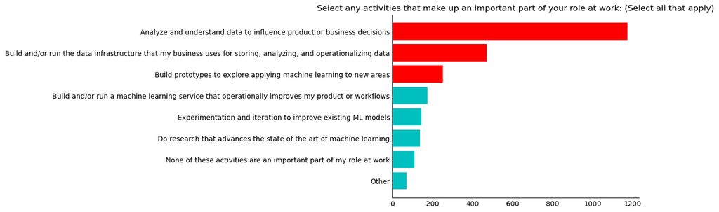

```python
response_summary = summarize_survey_response(survey_data, "Q28")
plot_response_summary(question_table, response_summary, "Q28")
```

## 探索資料分析師使用的程式語言

> Q12: What programming languages do you use on a regular basis? (Select all that apply)

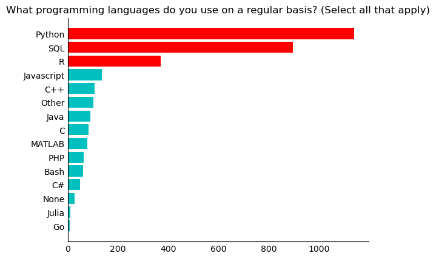

```python
response_summary = summarize_survey_response(survey_data, "Q12")
plot_response_summary(question_table, response_summary, "Q12")
```

## 探索資料分析師使用的整合開發環境、純文字編輯器

> Q13: Which of the following integrated development environments (IDE's) do you use on a regular basis? (Select all that apply)

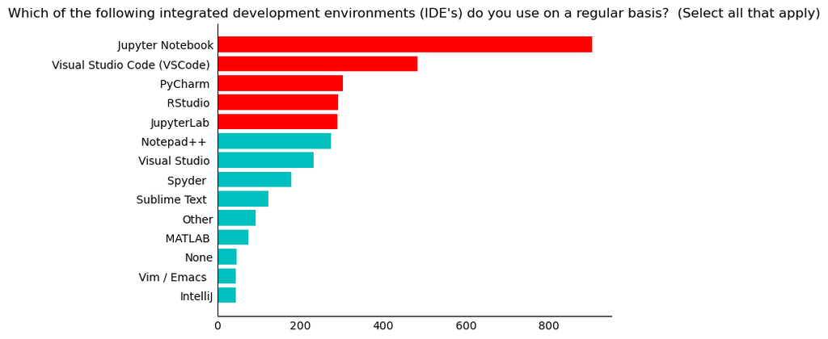

```python
response_summary = summarize_survey_response(survey_data, "Q13")
plot_response_summary(question_table, response_summary, "Q13", n=5)
```

## 探索資料分析師使用的視覺化模組、套件

> Q15: Do you use any of the following data visualization libraries on a regular basis? (Select all that apply)

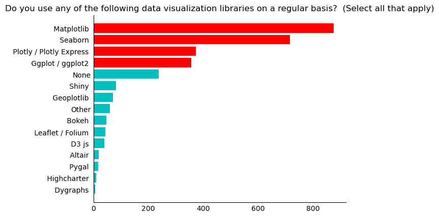

```python
response_summary = summarize_survey_response(survey_data, "Q15")
plot_response_summary(question_table, response_summary, "Q15", n=4)
```

## 探索資料分析師使用的商業智能軟體

> Q36: Do you use any of the following business intelligence tools? (Select all that apply)

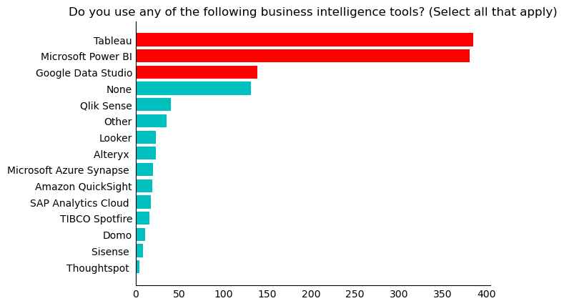

```python
response_summary = summarize_survey_response(survey_data, "Q36")
plot_response_summary(question_table, response_summary, "Q36")
```

## 探索資料分析師使用的機器學習模組、套件

> Q17: Which of the following machine learning frameworks do you use on a regular basis? (Select all that apply)

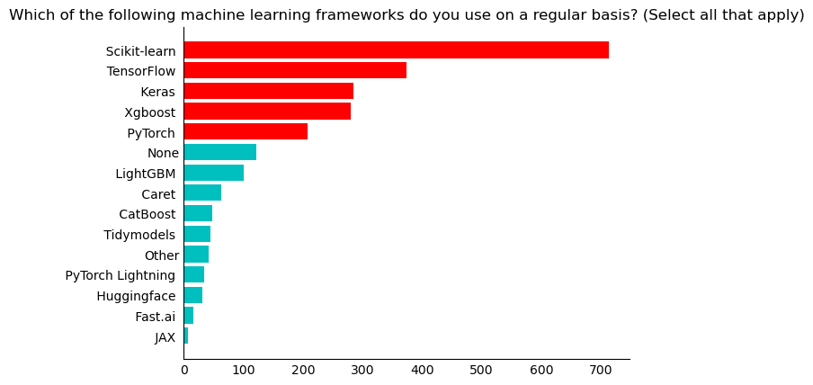

```python
response_summary = summarize_survey_response(survey_data, "Q17")
plot_response_summary(question_table, response_summary, "Q17", n=5)
```

## 探索資料分析師使用的關聯式資料庫管理系統

> Q35: Do you use any of the following data products (relational databases, data warehouses, data lakes, or similar)? (Select all that apply)

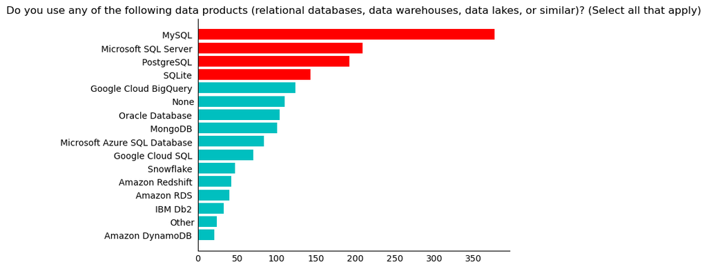

```python
response_summary = summarize_survey_response(survey_data, "Q35")
plot_response_summary(question_table, response_summary, "Q35", n=4)
```